# **QTW FINAL CASE STUDY SUMMER 2020 - RF ONLY**

```r
#data manipulation
library(tidyverse)
library(dplyr)
library(data.table)
#visualization
library(ggplot2)
library(skimr)
library(corrplot)
library(kableExtra)
#prediction
library(RSNNS) #older
library(neuralnet) #newer
library(randomForest)
library(e1071)
#analysis
library(caret) #one hot encoding
```

#### Introduction

data from - https://smu.box.com/s/k9x192jxm39enjw2wx8ouw2kopx33l32 classify column ‘y’ using features x0-x49 minimize cost on a theorhetical unknown dataset, where false positive = -10$ false negative = -500$ true positive/negative = -0$

find a model to reasonably minimize cost

include- confusion plot with costs average/predicted[ratio] as a model metric

```r
#file_name = file.choose()
#data_raw = read.csv(file_name)
data_raw = read.csv('D:/SMU/DS 7333 Quantify The World/qtw_final_project.csv')
```

#### EDA/Cleaning

```r
# #eda with skimr
# skim(data_raw) %>% dplyr::select(skim_type, skim_variable, n_missing)
# skim(data_raw) %>% dplyr::select(skim_type, skim_variable, numeric.mean)
# #add additional skimr output here
# skim(data_raw)
```

also note that the average value of y is 0.401, indicating only ~40% of rows have y = 1

```r
#remove rows with na
data_v1 <- data_raw[complete.cases(data_raw), ]
dim(data_v1)
```

```
## [1] 158534     51
```

from 160,000 to 158,534, removing all rows with NA loses 1,500 ish rows, or 0.9% of data

```r
#col 37 is dollar amounts stored as characters, need to convert
data_v1$x37 <- as.numeric(substr(data_v1$x37, 2, nchar(data_v1$x37))) #index string with substring to cut out the dollar sign and convert to numeric
#same for col 32
data_v1$x32 <- as.numeric(substr(data_v1$x32, 1, nchar(data_v1$x32)-1)) #same thing
```

ok, now we have numeric values for x37 instead of characters, run na removal again

```r
data_v1 <- data_v1[complete.cases(data_v1), ]
dim(data_v1)
```

```
## [1] 158480     51
```

### Categorical Encoding

```r
#looking at number of categorical variables in each non-numeric column
non_numeric_only <- data_v1[, !unlist(lapply(data_v1, is.numeric))]

for(i in 1:length(non_numeric_only)){
  print(table(non_numeric_only[, i]))
}
```

```
##
##         america    asia  euorpe
##      28    4420  137651   16381
##
##             Apr     Aug     Dev     Feb January    July     Jun     Mar     May
##      30    6701   29125      23     139       9   45140   40922    1221   21711
##     Nov     Oct   sept.
##     332    2385   10742
##
##              friday    monday   thurday   tuesday wednesday
##        30       556       484     29172     27697    100541
```

not too many labels to one hot encode

```r
#from caret
dmy24 <- dummyVars(" ~ .", data = non_numeric_only)
trsf24 <- data.frame(predict(dmy24, newdata = non_numeric_only))
head(trsf24)
```

```
##   x24 x24america x24asia x24euorpe x29 x29Apr x29Aug x29Dev x29Feb x29January
## 1   0          0       0         1   0      0      0      0      0          0
## 2   0          0       1         0   0      0      1      0      0          0
## 3   0          0       1         0   0      0      0      0      0          0
## 4   0          0       1         0   0      0      0      0      0          0
## 5   0          0       1         0   0      0      0      0      0          0
## 6   0          0       1         0   0      0      1      0      0          0
##   x29July x29Jun x29Mar x29May x29Nov x29Oct x29sept. x30 x30friday x30monday
## 1       1      0      0      0      0      0        0   0         0         0
## 2       0      0      0      0      0      0        0   0         0         0
## 3       1      0      0      0      0      0        0   0         0         0
## 4       1      0      0      0      0      0        0   0         0         0
## 5       1      0      0      0      0      0        0   0         0         0
## 6       0      0      0      0      0      0        0   0         0         0
##   x30thurday x30tuesday x30wednesday
## 1          0          1            0
## 2          0          0            1
## 3          0          0            1
## 4          0          0            1
## 5          0          1            0
## 6          0          0            1
```

```r
#add the columns to the actual dataset, drop the now redundant columns
data_v3 <- data_v1[, unlist(lapply(data_v1, is.numeric))] #remove x24, 29, 30
data_v3 <- cbind(data_v3, trsf24) #attach the one hot encoded data
head(data_v3)
```

```
##           x0         x1         x2       x3        x4          x5         x6
## 1 -0.1665627 -3.9615883   4.621113 2.481908 -1.800135   0.8046842   6.718751
## 2 -0.1498940 -0.5856755  27.839856 4.152333  6.426802  -2.4269429  40.477058
## 3 -0.3217069 -1.4298188  12.251561 6.586874 -5.304647 -11.3110898  17.812850
## 4 -0.2455944  5.0766774 -24.149632 3.637307  6.505811   2.2902240 -35.111751
## 5 -0.2733664  0.3063261 -11.352593 1.676758  2.928441  -0.6168245 -16.505817
## 6 -0.2267057 11.3503642  10.831367 5.182092 -2.236454  10.7162476  15.747993
##           x7         x8         x9          x10        x11        x12       x13
## 1 -14.789997 -1.0406730 -4.2049496   6.18746525  13.251523  25.665413 -5.017267
## 2  -6.725709  0.8964210  0.3301654 -11.70885866  -2.352809 -25.014934  9.799608
## 3  11.060572  5.3258804 -2.6329840   1.57264743  -4.170771  12.078602 -5.158498
## 4 -18.913592 -0.3370413 -5.5680762  -2.00025501 -19.286668  10.995330 -5.914378
## 5  27.532281  1.1997146 -4.3091048   6.66752962   1.965913 -28.106348 -1.258950
## 6 -15.900329 -0.1780023 10.9013056  -0.09016951  -6.062488   3.463613  1.853504
##          x14        x15       x16        x17       x18        x19       x20
```

[output cut: 55 more lines]

### correlation visualiazations

[figure not shown]

```r
library(ggcorrplot)
#c1 <- round(cor(data_v3[, c(48, 66:71)]), 2)

ggcorrplot(round(cor(data_v3[, (1:48)]), 2), hc.order = TRUE,
           type = 'lower',
           lab = TRUE,
           lab_size = 1,
           method = 'circle',
           colors = c('tomato2', 'white', 'springgreen3'),
           title = 'Correlogram of Encoded Weekdays',
           ggtheme = theme_bw)
```

[figure not shown]

```r
ggcorrplot(round(cor(data_v3[, c(48, 51:53)]), 2), hc.order = TRUE,
           type = 'lower',
           lab = TRUE,
           lab_size = 1,
           method = 'circle',
           colors = c('tomato2', 'white', 'springgreen3'),
           title = 'Correlogram of Encoded Weekdays',
           ggtheme = theme_bw)
```

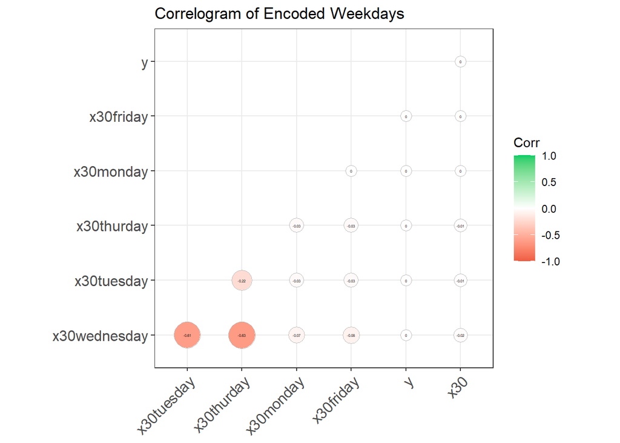

```r
ggcorrplot(round(cor(data_v3[, c(48, 66:71)]), 2), hc.order = TRUE,
           type = 'lower',
           lab = TRUE,
           lab_size = 1,
           method = 'circle',
           colors = c('tomato2', 'white', 'springgreen3'),
           title = 'Correlogram of Encoded Weekdays',
           ggtheme = theme_bw)
```

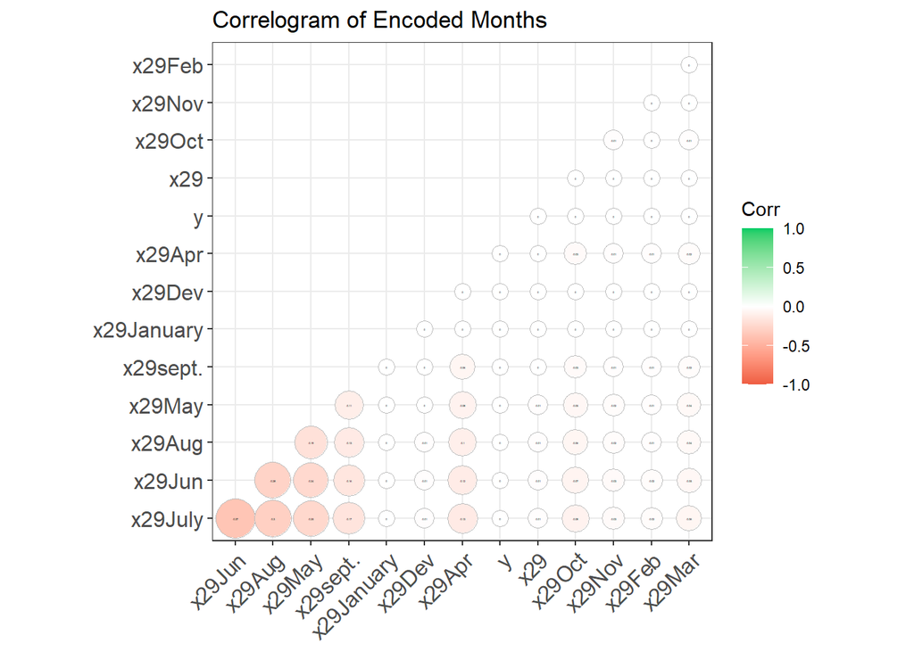

```r
ggcorrplot(round(cor(data_v3[, c(48, 53:65)]), 2), hc.order = TRUE,
           type = 'lower',
           lab = TRUE,
           lab_size = 0.5,
           method = 'circle',
           colors = c('tomato2', 'white', 'springgreen3'),
           title = 'Correlogram of Encoded Months',
           ggtheme = theme_bw)
```

```r
resultsv1 <- function(actual_values, predictions){
  ctable <- table(actual_values, predictions)
  cmat <- confusionMatrix(ctable)
  #print(cmat)
  #return(cmat)
  d_out <- (ctable[2, 1]*500 + ctable[1, 2] *10)
  s_output <- (paste('total cost of errors from model: $', format(d_out, big.mark = ',')))
  fn_chance <- ctable[2, 1]/(ctable[1, 1]+ctable[2, 1]) #%of negative predictions that are false negatives
  fp_chance <- ctable[1, 2]/(ctable[1, 2] + ctable[2, 2]) #%of positive predictions that are false positives
  return(list(cmat, s_output, d_out, fn_chance, fp_chance))
}
```

#### Model 5: Random Forest Classification

model5, random forest classification

```r
start.time <- Sys.time()

data_v3_trim <- data_v3[sample(1:dim(data_v3)[1], size = round(0.10* dim(data_v3)[1])), ]
train_index <- createDataPartition(data_v3_trim$y, p = 0.7, list = FALSE)
train_v3 <- data_v3_trim[train_index, ]
train_v3$y <- as.factor(train_v3$y)
test_v3 <- data_v3_trim[-train_index, ]
test_v3$y <- as.factor(test_v3$y)

rf5 <- randomForest(y ~., data = train_v3,
                    type = 'classification',
                    proximity = TRUE,
                    importance = TRUE)
print(rf5)
```

```
##
## Call:
##  randomForest(formula = y ~ ., data = train_v3, type = "classification",      proximity = TRUE, importance = TRUE)
##                Type of random forest: classification
##                      Number of trees: 500
## No. of variables tried at each split: 8
##
##         OOB estimate of  error rate: 12.61%
## Confusion matrix:
##      0    1 class.error
## 0 6094  463  0.07061156
## 1  936 3601  0.20630372
```

```r
end.time <- Sys.time()
time.taken <- end.time - start.time
print(paste('time ellapsed:', time.taken))
```

```
## [1] "time ellapsed: 2.27583726644516"
```

```r
#costs from training set
resultsv1(rf5$predicted, train_v3$y)
```

```
## [[1]]
## Confusion Matrix and Statistics
##
##              predictions
## actual_values    0    1
##             0 6094  936
##             1  463 3601
##
##                Accuracy : 0.8739
##                  95% CI : (0.8676, 0.88)
##     No Information Rate : 0.591
##     P-Value [Acc > NIR] : < 2.2e-16
##
##                   Kappa : 0.7349
##
##  Mcnemar's Test P-Value : < 2.2e-16
##
##             Sensitivity : 0.9294
##             Specificity : 0.7937
##          Pos Pred Value : 0.8669
##          Neg Pred Value : 0.8861
##              Prevalence : 0.5910
##          Detection Rate : 0.5493
##    Detection Prevalence : 0.6337
##       Balanced Accuracy : 0.8615
##
##        'Positive' Class : 0
##
##
## [[2]]
## [1] "total cost of errors from model: $ 240,860"
##
## [[3]]
## [1] 240860
##
## [[4]]
## [1] 0.07061156
##
## [[5]]
## [1] 0.2063037
```

apply random forest model to the test data

```r
pred5 <- predict(rf5, newdata = test_v3)
m5_results <- resultsv1(as.factor(test_v3$y), pred5)
m5_results
```

```
## [[1]]
## Confusion Matrix and Statistics
##
##              predictions
## actual_values    0    1
##             0 2636  169
##             1  392 1557
##
##                Accuracy : 0.882
##                  95% CI : (0.8725, 0.891)
##     No Information Rate : 0.6369
##     P-Value [Acc > NIR] : < 2.2e-16
##
##                   Kappa : 0.7517
##
##  Mcnemar's Test P-Value : < 2.2e-16
##
##             Sensitivity : 0.8705
##             Specificity : 0.9021
##          Pos Pred Value : 0.9398
##          Neg Pred Value : 0.7989
##              Prevalence : 0.6369
##          Detection Rate : 0.5545
##    Detection Prevalence : 0.5900
##       Balanced Accuracy : 0.8863
##
##        'Positive' Class : 0
##
##
## [[2]]
## [1] "total cost of errors from model: $ 197,690"
##
## [[3]]
## [1] 197690
##
## [[4]]
## [1] 0.1294584
##
## [[5]]
## [1] 0.09791425
```

### Random Forest Feature Importance

```r
m5_importance <- as.data.frame(importance(rf5))
head(m5_importance[order(-m5_importance[1]), ])
```

```
##            0        1 MeanDecreaseAccuracy MeanDecreaseGini
## x23 52.23882 45.16345             55.66977         357.2120
## x48 48.34356 46.30113             55.40413         249.1120
## x20 41.37800 40.58056             46.71481         293.2578
## x12 38.08436 35.20893             41.16058         208.1219
## x42 38.03789 38.16630             44.03374         212.2542
## x49 37.83987 41.96169             45.50633         270.9921
```

```r
head(m5_importance[order(-m5_importance[2]), ])
```

```
##            0        1 MeanDecreaseAccuracy MeanDecreaseGini
## x48 48.34356 46.30113             55.40413         249.1120
## x23 52.23882 45.16345             55.66977         357.2120
## x49 37.83987 41.96169             45.50633         270.9921
## x28 29.49071 41.31886             44.63335         193.7609
## x20 41.37800 40.58056             46.71481         293.2578
## x27 31.84603 40.12620             43.61488         188.9368
```

```r
head(m5_importance[order(-m5_importance[3]), ])
```

```
##            0        1 MeanDecreaseAccuracy MeanDecreaseGini
## x23 52.23882 45.16345             55.66977         357.2120
## x48 48.34356 46.30113             55.40413         249.1120
## x37 34.17583 38.28889             48.43011         211.1056
## x20 41.37800 40.58056             46.71481         293.2578
## x49 37.83987 41.96169             45.50633         270.9921
## x28 29.49071 41.31886             44.63335         193.7609
```

```r
head(m5_importance[order(-m5_importance[4]), ])
```

```
##            0        1 MeanDecreaseAccuracy MeanDecreaseGini
## x23 52.23882 45.16345             55.66977         357.2120
## x20 41.37800 40.58056             46.71481         293.2578
## x49 37.83987 41.96169             45.50633         270.9921
## x48 48.34356 46.30113             55.40413         249.1120
## x40 27.59496 30.74904             37.28205         216.5697
## x42 38.03789 38.16630             44.03374         212.2542
```

Variable importance from a Random Forest model is determined by looking at the prediction error rate for each variable at each ‘fork’ in the decision tree. the importance of that variable is calculated using the ratio of the number of times that variable lead to a desired classification.

Mean Decrease in Accuracy is a measure of how much the accuracy of a classification drops when that variable is *excluded* from the tree. Therefore variables with higher mean decrease accuracy are more important to the model.

A table of variable importance shows that x23, x48, and x20 were the strongest indicators/most important variables in making a ‘0’ classification.

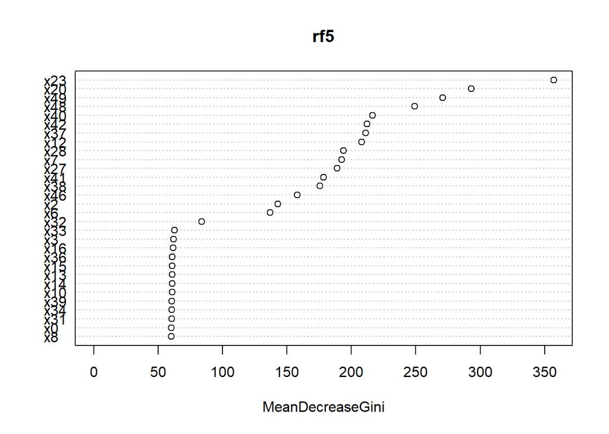

```r
varImpPlot(rf5, type = 2)
```

Diverging Bar Graph

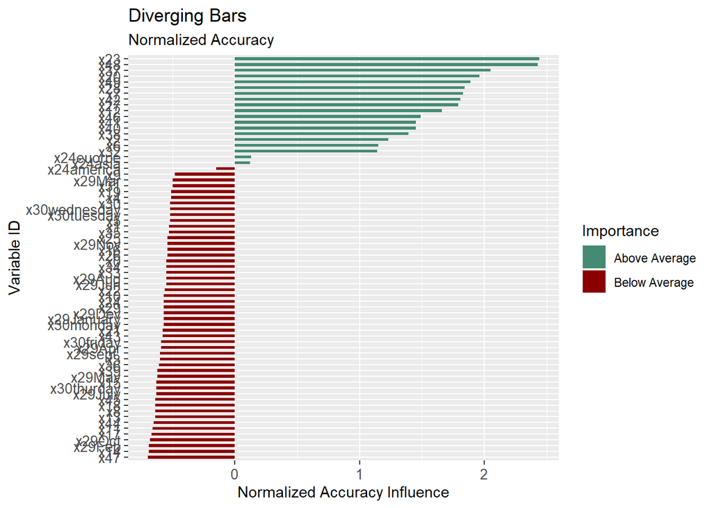

```r
m5_importance <- as.data.frame(importance(rf5))
#head(m5_importance[order(-m5_importance[1]), ])
#head(m5_importance[order(-m5_importance[2]), ])
#head(m5_importance[order(m5_importance[3]), ])
#head(m5_importance[order(-m5_importance[4]), ])
#center importance weights on zero
m5_importance$z_gini <- round((m5_importance$MeanDecreaseGini - mean(m5_importance$MeanDecreaseGini))/sd(m5_importance$MeanDecreaseGini), 2)
m5_importance$z_acc <- round((m5_importance$MeanDecreaseAccuracy - mean(m5_importance$MeanDecreaseAccuracy))/sd(m5_importance$MeanDecreaseAccuracy), 2)
m5_importance$z_0 <- round((m5_importance$'0' - mean(m5_importance$'0'))/sd(m5_importance$'0'), 2)
m5_importance$z_1 <- round((m5_importance$'1' - mean(m5_importance$'1'))/sd(m5_importance$'1'), 2)

m5_importance$acc_type <- ifelse(m5_importance$z_acc < 0, 'below', 'above') #create category for entries over/under zero
m5_importance <- m5_importance[order(-m5_importance[3]), ] #sort by accuracy
m5_importance$var_name <- rownames(m5_importance) #create column with varnames
m5_importance$var_name <- factor(m5_importance$var_name, levels = m5_importance$var_name)


v5 <- ggplot(m5_importance, aes(x = reorder(var_name, desc(var_name)), y = z_acc, label = 'Normalized Accuracy'))+
  geom_bar(stat = 'identity', aes(fill = acc_type), width = 0.5) +
  scale_fill_manual(name = 'Importance',
                    labels = c('Above Average', 'Below Average'),
                    values = c('above' = 'aquamarine4', 'below' = 'darkred')) +
  ggtitle('Diverging Bars', subtitle = 'Normalized Accuracy') +
  coord_flip() +
  theme(axis.text= element_text(size = 10))+
  xlab('Variable ID') + ylab('Normalized Accuracy Influence')

show(v5)
```

```r
ggsave(filename = 'v1_rf_importance.jpg', plot = v5, path = 'D:/SMU/DS 7333 Quantify The World')
```

additional experiment - RF with less variables

```r
data_v4 <- data_v3[, c('y', as.character(m5_importance$var_name[(m5_importance$acc_type == 'above')]))]
head(data_v4)
```

```
##   y        x23        x48      x37       x20        x49        x28         x7
## 1 0   3.553013  0.1515890  1313.96 -1.909114  -8.040166 -18.473784 -14.789997
## 2 0  10.590601 -0.3202828  1962.78 -5.809984  16.719974   3.749377  -6.725709
## 3 0  -5.270615 -2.0908035   430.47  1.700321  -7.869421  11.522448  11.060572
## 4 0 -11.484431  1.8060702 -2366.29  1.923670  -7.670847  30.595226 -18.913592
## 5 1 -15.998166 -0.8949417  -620.66 -9.026317  15.724742  -4.094084  27.532281
## 6 0   2.225120 -2.6095527  -196.45  5.737036 -20.320179   5.567174 -15.900329
##         x42        x27        x12       x46         x41         x40         x38
## 1  5.414063  1.0051306  25.665413  60.78143  -1.4971171 -10.6122002  -1.3537289
## 2  4.490915  0.7510861 -25.014934  15.80570  36.2927898   2.1474265  32.8168041
## 3  9.088864  4.1710884  12.078602  30.85642  -0.3684912  -0.8631368  -0.3331985
## 4 -7.467775  9.2155691  10.995330 -72.42457  15.6915455  12.0844211  14.1886688
## 5 -5.229937  1.8111816 -28.106348 -14.08544 -13.9112973  30.0047266 -12.5789260
## 6  6.402343 14.1627353   3.463613  19.17237  -7.2503103   3.0912608  -6.5559031
##           x2         x6   x32 x24euorpe x24asia
## 1   4.621113   6.718751  0.00         1       0
## 2  27.839856  40.477058 -0.02         0       1
## 3  12.251561  17.812850 -0.01         0       1
## 4 -24.149632 -35.111751  0.01         0       1
## 5 -11.352593 -16.505817  0.01         0       1
## 6  10.831367  15.747993 -0.01         0       1
```

```r
start.time <- Sys.time()

data_v3_trim <- data_v4[sample(1:dim(data_v4)[1], size = round(0.10* dim(data_v4)[1])), ]
train_index <- createDataPartition(data_v3_trim$y, p = 0.7, list = FALSE)
train_v3 <- data_v3_trim[train_index, ]
train_v3$y <- as.factor(train_v3$y)
test_v3 <- data_v3_trim[-train_index, ]
test_v3$y <- as.factor(test_v3$y)

rf5 <- randomForest(y ~., data = train_v3,
                    type = 'classification',
                    proximity = TRUE,
                    importance = TRUE)
print(rf5)
```

```
##
## Call:
##  randomForest(formula = y ~ ., data = train_v3, type = "classification",      proximity = TRUE, importance = TRUE)
##                Type of random forest: classification
##                      Number of trees: 500
## No. of variables tried at each split: 4
##
##         OOB estimate of  error rate: 9.16%
## Confusion matrix:
##      0    1 class.error
## 0 6308  357  0.05356339
## 1  659 3770  0.14879205
```

```r
end.time <- Sys.time()
time.taken <- end.time - start.time
print(paste('time ellapsed:', time.taken))
```

```
## [1] "time ellapsed: 1.44948468208313"
```

```r
pred5 <- predict(rf5, newdata = test_v3)
m5_results <- resultsv1(as.factor(test_v3$y), pred5)
m5_results
```

```
## [[1]]
## Confusion Matrix and Statistics
##
##              predictions
## actual_values    0    1
##             0 2710  162
##             1  298 1584
##
##                Accuracy : 0.9032
##                  95% CI : (0.8945, 0.9115)
##     No Information Rate : 0.6327
##     P-Value [Acc > NIR] : < 2.2e-16
##
##                   Kappa : 0.7952
##
##  Mcnemar's Test P-Value : 3.086e-10
##
##             Sensitivity : 0.9009
##             Specificity : 0.9072
##          Pos Pred Value : 0.9436
##          Neg Pred Value : 0.8417
##              Prevalence : 0.6327
##          Detection Rate : 0.5700
##    Detection Prevalence : 0.6041
##       Balanced Accuracy : 0.9041
##
##        'Positive' Class : 0
##
##
## [[2]]
## [1] "total cost of errors from model: $ 150,620"
##
## [[3]]
## [1] 150620
##
## [[4]]
## [1] 0.09906915
##
## [[5]]
## [1] 0.09278351
```

And even better performance from the reduced variable inputs